# New York Airbnb Analysis

```r
#Viewing and cleaning data after importing it into RStudio
head(airbnb)
```

| Host Id | Host Since | Name | Borough | Property Type | Review Scores Rating (bin) | Room Type | Zipcode | Beds | Number of Records | Number Of Reviews | Price | Review Scores Rating |
| --- | --- | --- | --- | --- | --- | --- | --- | --- | --- | --- | --- | --- |
| 5162530 |  | 1 Bedroom in Prime Williamsburg | Brooklyn | Apartment | NA | Entire home/apt | 11249 | 1 | 1 | 0 | 145 | NA |
| 33134899 |  | Sunny, Private room in Bushwick | Brooklyn | Apartment | NA | Private room | 11206 | 1 | 1 | 1 | 37 | NA |
| 39608626 |  | Sunny Room in Harlem | Manhattan | Apartment | NA | Private room | 10032 | 1 | 1 | 1 | 28 | NA |
| 500 | 2008-06-26 | Gorgeous 1 BR with Private Balcony | Manhattan | Apartment | NA | Entire home/apt | 10024 | 3 | 1 | 0 | 199 | NA |
| 500 | 2008-06-26 | Trendy Times Square Loft | Manhattan | Apartment | 95 | Private room | 10036 | 3 | 1 | 39 | 549 | 96 |
| 1039 | 2008-07-25 | Big Greenpoint 1BD w/ Skyline View | Brooklyn | Apartment | 100 | Entire home/apt | 11222 | 1 | 1 | 4 | 149 | 100 |

```r
data_unique=airbnb[!duplicated(airbnb),]
dt=na.omit(data_unique)
head(dt)
```

| Host Id | Host Since | Name | Borough | Property Type | Review Scores Rating (bin) | Room Type | Zipcode | Beds | Number of Records | Number Of Reviews | Price | Review Scores Rating |
| --- | --- | --- | --- | --- | --- | --- | --- | --- | --- | --- | --- | --- |
| 500 | 2008-06-26 | Trendy Times Square Loft | Manhattan | Apartment | 95 | Private room | 10036 | 3 | 1 | 39 | 549 | 96 |
| 1039 | 2008-07-25 | Big Greenpoint 1BD w/ Skyline View | Brooklyn | Apartment | 100 | Entire home/apt | 11222 | 1 | 1 | 4 | 149 | 100 |
| 1783 | 2008-08-12 | Amazing Also | Manhattan | Apartment | 100 | Entire home/apt | 10004 | 1 | 1 | 9 | 250 | 100 |
| 2078 | 2008-08-15 | Colorful, quiet, & near the subway! | Brooklyn | Apartment | 90 | Private room | 11201 | 1 | 1 | 80 | 90 | 94 |
| 2339 | 2008-08-20 | East Village Cocoon: 2 Bedroom Flat | Manhattan | Apartment | 90 | Entire home/apt | 10009 | 2 | 1 | 95 | 270 | 90 |
| 2339 | 2008-08-20 | Lovely 2 Bedroom East Village Nest | Manhattan | Apartment | 95 | Entire home/apt | 10009 | 2 | 1 | 23 | 290 | 96 |

```r
#Quick Descriptive Statistics on Pricing and Rating
summary(dt$Price)
```

```
   Min. 1st Qu.  Median    Mean 3rd Qu.    Max.
   10.0    85.0   125.0   154.8   190.0 10000.0
```

```r
summary(dt$`Review Scores Rating`)
```

```
   Min. 1st Qu.  Median    Mean 3rd Qu.    Max.
  20.00   89.00   94.00   91.99  100.00  100.00
```

```r
#Checking the airbnb with minimum pricing
dt[dt$Price=="10", ]
```

| Host Id | Host Since | Name | Borough | Property Type | Review Scores Rating (bin) | Room Type | Zipcode | Beds | Number of Records | Number Of Reviews | Price | Review Scores Rating |
| --- | --- | --- | --- | --- | --- | --- | --- | --- | --- | --- | --- | --- |
| 14381346 | 2014-04-16 | Small sofa | Bronx | House | 100 | Shared room | 10462 | 1 | 1 | 2 | 10 | 100 |

```r
NA
```

The place charging $10 is actually a house in Bronx called “Small Sofa”, offering a shared one room. It has been available for booking since 2014 and has a rating of 100.

```r
#Checking the airbnb with maximum pricing.
dt[dt$Price=="10000", ]
```

| Host Id | Host Since | Name | Borough | Property Type | Review Scores Rating (bin) | Room Type | Zipcode | Beds | Number of Records | Number Of Reviews | Price | Review Scores Rating |
| --- | --- | --- | --- | --- | --- | --- | --- | --- | --- | --- | --- | --- |
| 23248648 | 2014-11-02 | NO LONGER BOOKING RESERVATIONS | Manhattan | Apartment | 95 | Entire home/apt | 10025 | 2 | 1 | 21 | 10000 | 95 |

```r
NA
```

The place charging $10,000 is an entire apartment in Manhattan offering two beds with a review score rating of 95. It has been on the market since 2014, although it looks like it is no longer accepting reservations.

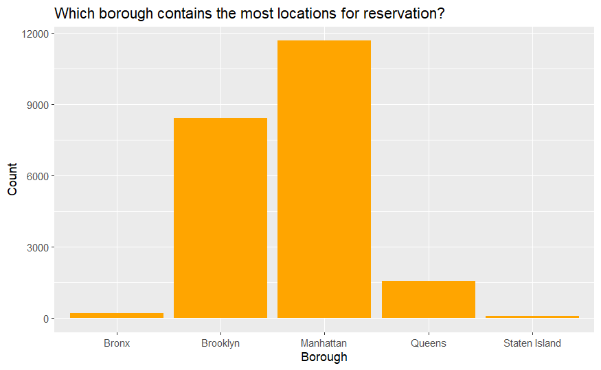

```r
#Which borough has the most airbnb locations available?
library(ggplot2)
ggplot(dt, aes(x=Borough))+geom_bar(stat="count",fill="orange")+labs(title="Which borough contains the most locations for reservation?", y="Count")
```

Manhattan contains the most places for reservation, followed by Brooklyn, Queens, Bronx and Staten Island.

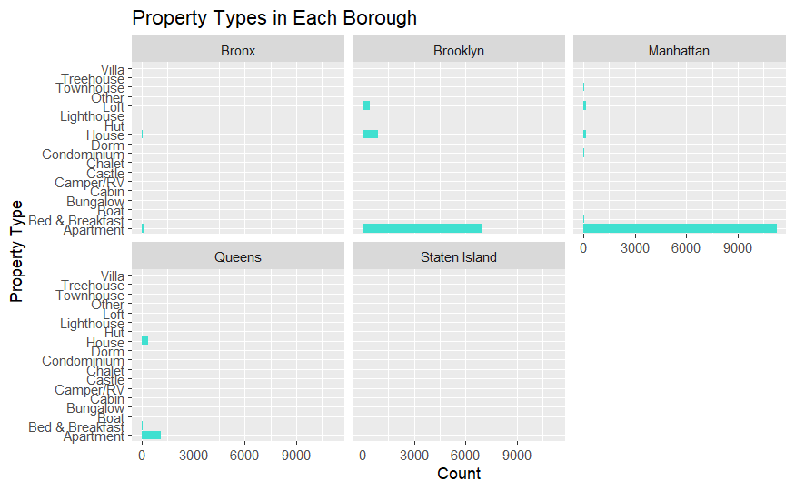

```r
#What are the property types in each borough?
ggplot(dt, aes(y=dt$`Property Type`))+geom_bar(stat="count",fill="turquoise")+labs(title="Property Types in Each Borough", y= "Property Type", x="Count")+facet_wrap(~Borough)
```

The property type most available across all boroughs are apartments, followed by houses,then lofts. It is interesting how apartments are the most common. This may be due to changes in social culture favoring temporal living habits.

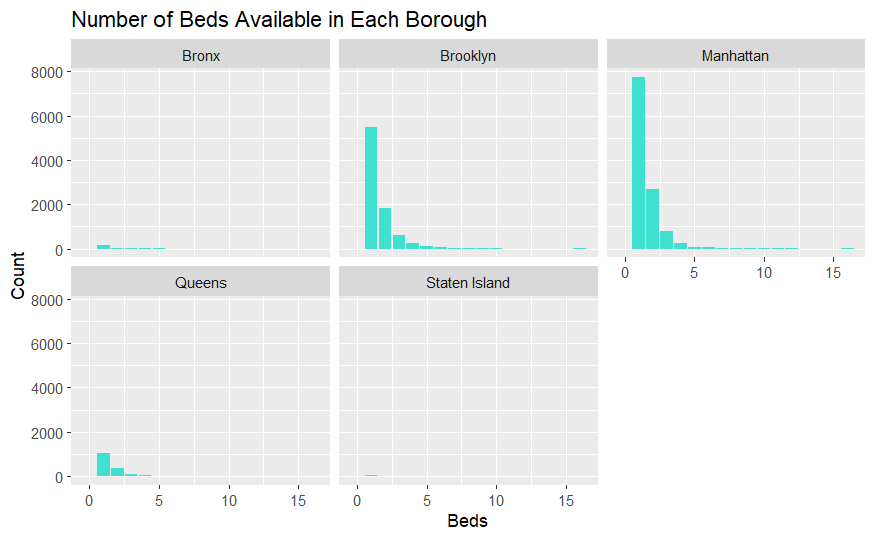

```r
#What are the number of beds in each borough?
ggplot(dt, aes(x= Beds))+geom_bar(stat="count", fill="turquoise")+labs(title="Number of Beds Available in Each Borough", y= "Count", x="Beds")+facet_wrap(~Borough)
```

One bed spaces are most common in each borough as well, perhaps indicating the societal changes favoring temporal habits; or simply people wanting to rent their guest rooms for passive income.

```r
#What are the places sporting 16 beds?
dt[dt$Beds=="16", ]
```

| Host Id | Host Since | Name | Borough | Property Type | Review Scores Rating (bin) | Room Type | Zipcode | Beds | Number of Records | Number Of Reviews | Price | Review Scores Rating |
| --- | --- | --- | --- | --- | --- | --- | --- | --- | --- | --- | --- | --- |
| 1420300 | 2011-11-18 | 5 Bathrooms 8 Bedrooms 24 Real Beds | Brooklyn | House | 95 | Entire home/apt | 11216 | 16 | 1 | 19 | 1000 | 98 |
| 1420300 | 2011-11-18 | 8 Bedrooms 5 Baths 20 mnts to SOHO | Brooklyn | House | 90 | Entire home/apt | 11216 | 16 | 1 | 36 | 1000 | 92 |
| 1495196 | 2011-12-11 | HOT SPOT FOR 20 AND 30 SOMETHING'S | Brooklyn | House | 75 | Entire home/apt | 11233 | 16 | 1 | 12 | 130 | 75 |
| 2472305 | 2012-05-26 | Artist's Ditmas Pk 5 bedroom house | Brooklyn | House | 90 | Entire home/apt | 11226 | 16 | 1 | 41 | 309 | 92 |
| 2675644 | 2012-06-18 | Famous Victorian Mansion~ | Staten Island | House | 90 | Entire home/apt | 10301 | 16 | 1 | 6 | 750 | 93 |
| 16903170 | 2014-06-17 | Super Luxury Townhouse-Sleeps 16!! | Manhattan | House | 95 | Entire home/apt | 10028 | 16 | 1 | 48 | 1500 | 96 |
| 20270339 | 2014-08-19 | JEWEL OF FRESH MEADOWS 5bedroom | Queens | House | 95 | Entire home/apt | 11366 | 16 | 1 | 6 | 350 | 97 |
| 26900762 | 2015-01-29 | Large Groups/7BR/4BA Home/$1500/USD | Brooklyn | House | 100 | Entire home/apt | 11205 | 16 | 1 | 2 | 1500 | 100 |
| 38204255 | 2015-07-12 | Beautiful Midtown Loft | Manhattan | Apartment | 100 | Entire home/apt | 10018 | 16 | 1 | 2 | 350 | 100 |
| 42037915 | 2015-08-20 | A home; a quick walk to NYC subway | Brooklyn | House | 100 | Entire home/apt | 11229 | 16 | 1 | 1 | 104 | 100 |

```r
NA
```

On the other hand, 16 bed residences are commonly entire houses in Brooklyn, echoing a form of duration and stability compared to the one bed apartments.

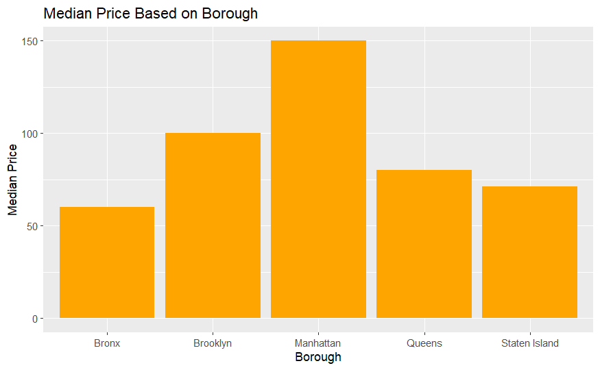

```r
#Average Pricing in each of the boroughs

dt %>%
  group_by(Borough) %>%
  summarise(median_price = median(Price)) %>%
  ggplot(aes(x = factor(Borough), y = median_price)) +
  geom_col(fill="orange") +
  labs(x = "Borough", y = "Median Price", title = "Median Price Based on Borough")
```

```r
NA
NA
```

Median prices are higher in Manhattan, followed by Brooklyn, Queens, Staten Island, and Bronx. Since median is less affected by extreme values(like the $10,000 Airbnb), it is best to utilize median to describe the central tendency of prices.

Conclusion:

Based on the analysis,it is evident that New York Airbnb median pricing depends on the borough. Locations in Manhattan and Brooklyn are most expensive. Furthermore, one bed apartments are most common in the market, across all boroughs. While this may be idle for solo travelers or couples, it may not be best for large families. Thus in this situation, Brooklyn may be best for accommodation.